# Analysis of Turkey’s Trade with Selected Countries

Dec 26<sup>th</sup>, 2018

## Team Members & Abstract

- [Busra Koc](https://mef-bda503.github.io/pj18-busraakoc/)
- [Emre Kemerci](https://mef-bda503.github.io/pj18-EmreKemerci/)
- [Muharrem Cakir](https://mef-bda503.github.io/pj18-muharremcakir81/)
- [Omer Bayir](https://mef-bda503.github.io/pj18-omerbayir/)
- [Salih Ucar](https://mef-bda503.github.io/pj18-ucarsal/)

In this term project, trade statistics data of Turkey against the G7 countries and 3 more countries (Russia, India, China) is analysed. The aim of the project is to analyze Turkey’s export and import characteristics by product groups considering the trade value and quantities.

The purpose of the analysis is to understand the Turkey’s trade Statistics for two way and with ten important countries.

Describe Turkey’s the trade deficit with the country,year and product dimensions. Try to clear which factors effects deficit in trade, and is there relation deficit and other financials.

A clear understanding of the data to see if we can locate useful insights about which products and countries will remain the deficit and wich of them will be strategic for Turkey

## Explanation of Raw Data

- 10 countries’ trade data against Turkey from [Trademap.org](https://trademap.org/Index.aspx) as 4 seperate excel tables, Export&Import Quantity and Export&Import Values

```
## Observations: 12,223
## Variables: 13
## $ Country       <chr> "Canada", "Canada", "Canada", "Canada", "Canada"...
## $ Product_Code  <chr> "TOTAL", "7214", "6907", "2523", "7208", "6802",...
## $ Product_Label <chr> "All products", "Bars and rods, of iron or non-a...
## $ Quantity_2013 <dbl> NA, 131711, 1795, 22000, 220, 46950, 19782, 2821...
## $ Unit1         <chr> "No quantity", "Tons", "Tons", "Tons", "Tons", "...
## $ Quantity_2014 <dbl> NA, 133195, 2560, 54210, 157114, 49668, 38396, 1...
## $ Unit2         <chr> "No quantity", "Tons", "Tons", "Tons", "Tons", "...
## $ Quantity_2015 <dbl> NA, 1085, 2291, 78195, 10756, 38561, 29677, 4219...
## $ Unit3         <chr> "No quantity", "Tons", "Tons", "Tons", "Tons", "...
## $ Quantity_2016 <dbl> NA, 1759, 1935, 62500, 38354, 33166, 19759, 2239...
## $ Unit4         <chr> "No quantity", "Tons", "Tons", "Tons", "Tons", "...
## $ Quantity_2017 <dbl> 0, 220831, 140214, 129930, 80459, 35413, 34646, ...
## $ Unit5         <chr> "No quantity", "Tons", "Tons", "Tons", "Tons", "...
```

## Explanation of Raw Data

```
## Observations: 12,222
## Variables: 8
## $ Country       <chr> "Canada", "Canada", "Canada", "Canada", "Canada"...
## $ Product_Code  <chr> "7214", "8703", "8901", "0802", "8902", "7208", ...
## $ Product_Label <chr> "Bars and rods, of iron or non-alloy steel, not ...
## $ Value_2013    <dbl> 73607, 13976, 0, 57640, 0, 211, 895, 40420, 1052...
## $ Value_2014    <dbl> 73814, 2485, 0, 65460, 0, 96558, 1227, 46362, 11...
## $ Value_2015    <dbl> 616, 2477, 62, 105122, 0, 5033, 1052, 37154, 129...
## $ Value_2016    <dbl> 863, 94, 66747, 94623, 0, 18777, 832, 30918, 171...
## $ Value_2017    <dbl> 106068, 87274, 84922, 75731, 45504, 44261, 40668...
```

## Data Preparation

### Joining Quantity, Value Data, Product Labels with 2 Digit Product Codes

```
## Observations: 12,223
## Variables: 16
## $ Country       <chr> "Canada", "Canada", "Canada", "Canada", "Canada"...
## $ Product_Code  <chr> "TOTAL", "7214", "6907", "2523", "7208", "6802",...
## $ Unit          <chr> "No quantity", "Tons", "Tons", "Tons", "Tons", "...
## $ Quantity_2013 <dbl> NA, 131711, 1795, 22000, 220, 46950, 19782, 2821...
## $ Quantity_2014 <dbl> NA, 133195, 2560, 54210, 157114, 49668, 38396, 1...
## $ Quantity_2015 <dbl> NA, 1085, 2291, 78195, 10756, 38561, 29677, 4219...
## $ Quantity_2016 <dbl> NA, 1759, 1935, 62500, 38354, 33166, 19759, 2239...
## $ Quantity_2017 <dbl> 0, 220831, 140214, 129930, 80459, 35413, 34646, ...
## $ Product_Label <chr> NA, "Bars and rods, of iron or non-alloy steel, ...
## $ Value_2013    <dbl> NA, 73607, 895, 1531, 211, 40420, 16625, 37956, ...
## $ Value_2014    <dbl> NA, 73814, 1227, 3961, 96558, 46362, 32160, 1484...
## $ Value_2015    <dbl> NA, 616, 1052, 5810, 5033, 37154, 23569, 6140, 0...
## $ Value_2016    <dbl> NA, 863, 832, 4590, 18777, 30918, 12319, 24849, ...
## $ Value_2017    <dbl> NA, 106068, 40668, 8801, 44261, 30766, 27136, 27...
## $ PcodeTwo      <chr> "TO", "72", "69", "25", "72", "68", "73", "73", ...
## $ X__2          <chr> NA, "Iron and steel", "Ceramic products", "Salt;...
```

## Data Preparation

### Collating Same Type of Variables

```
## Observations: 61,100
## Variables: 9
## $ Country       <chr> "Canada", "Canada", "Canada", "Canada", "Canada"...
## $ PcodeTwo      <chr> "72", "69", "25", "72", "68", "73", "73", "26", ...
## $ X__2          <chr> "Iron and steel", "Ceramic products", "Salt; sul...
## $ Product_Code  <chr> "7214", "6907", "2523", "7208", "6802", "7306", ...
## $ Product_Label <chr> "Bars and rods, of iron or non-alloy steel, not ...
## $ Unit          <chr> "Tons", "Tons", "Tons", "Tons", "Tons", "Tons", ...
## $ Quantity      <dbl> 131711, 1795, 22000, 220, 46950, 19782, 28212, N...
## $ year          <chr> "2013", "2013", "2013", "2013", "2013", "2013", ...
## $ Values        <dbl> 73607, 895, 1531, 211, 40420, 16625, 37956, 0, 0...
```

## Analysis

### Breakdown of Total Export and Import of Turkey Over Countries

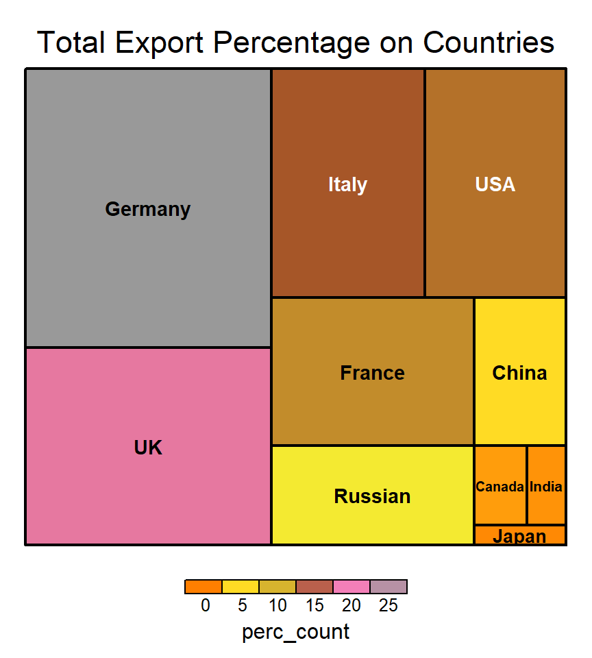

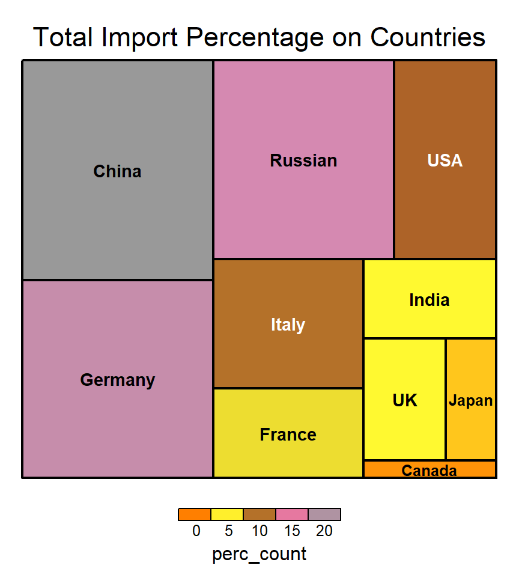

## Analysis

### Breakdown of Total Export and Import of Turkey Over Countries

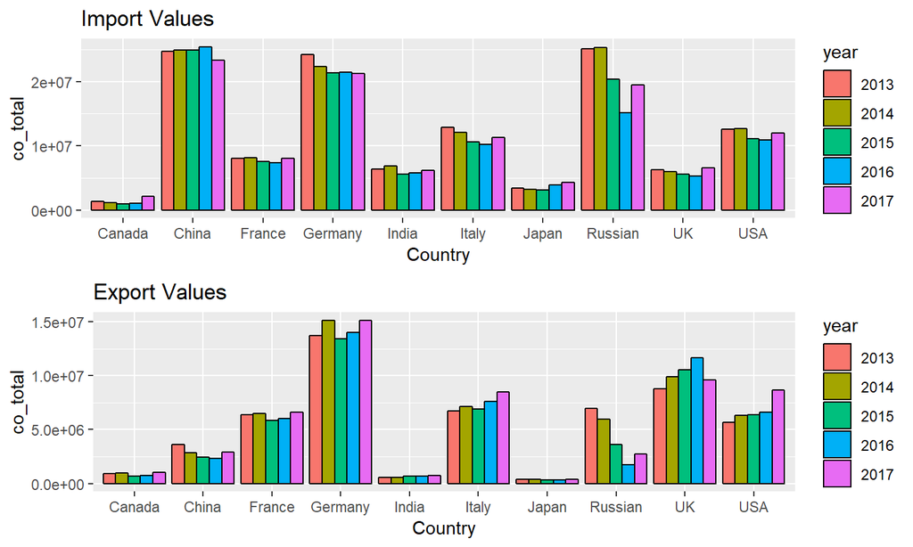

## Analysis

### Year over Year Changes in Trade Values

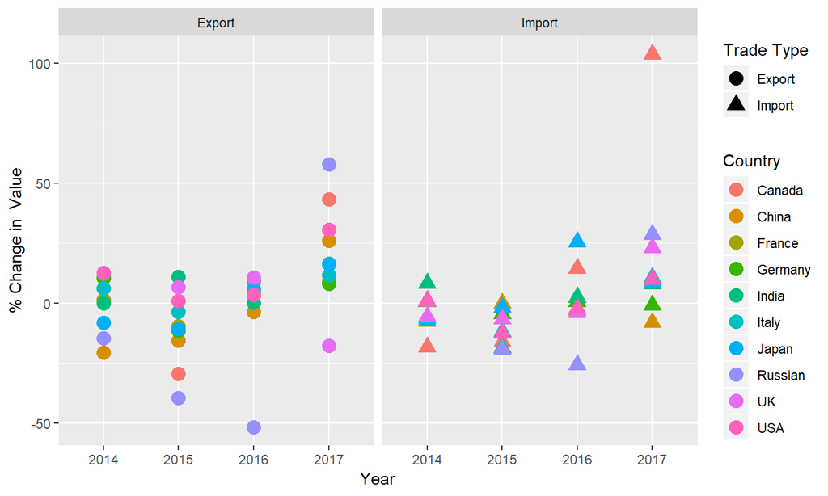

## Analysis

### Year over Year Changes in Trade Values - Exports to Canada

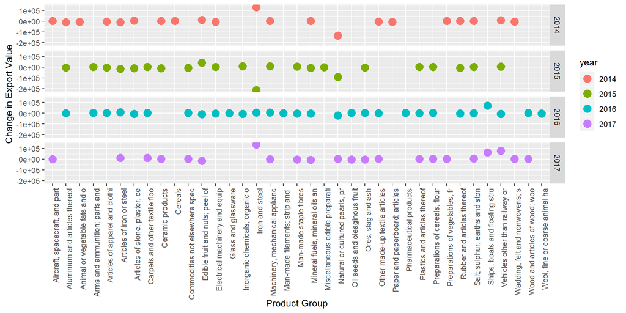

## Analysis

### Year over Year Changes in Trade Values - Imports From Canada

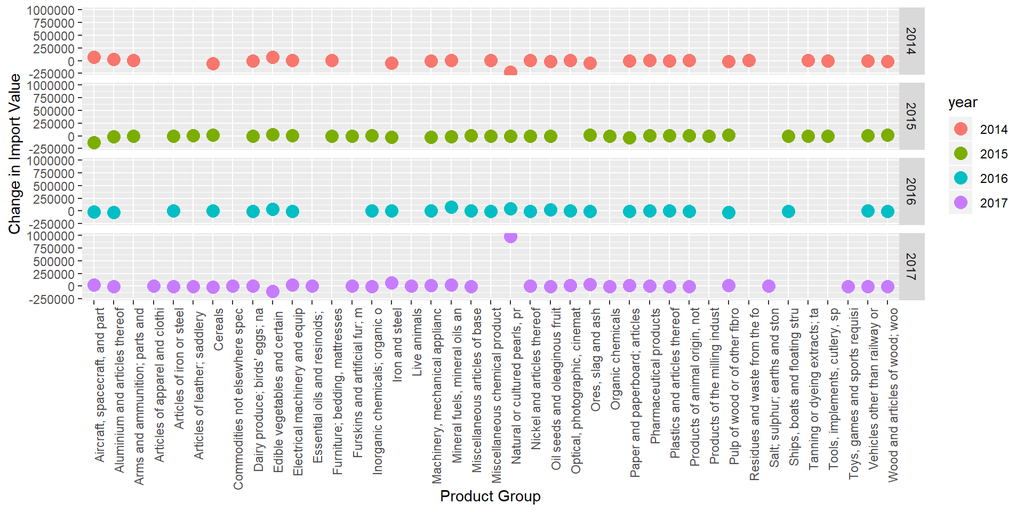

## Analysis

### Year over Year Changes in Trade Values - Exports to Russia

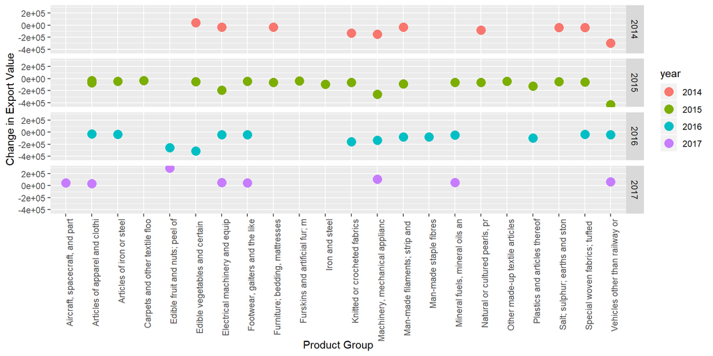

## Analysis

### Year over Year Changes in Trade Values - Imports From Russia

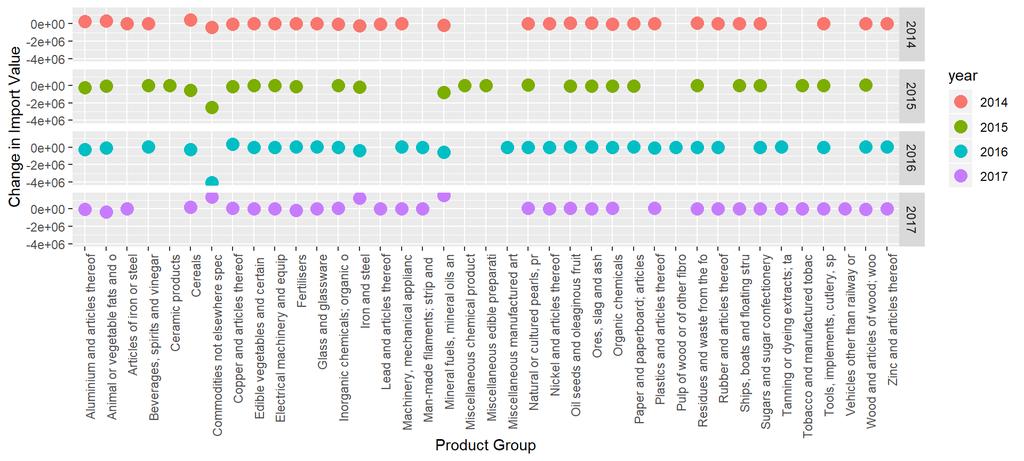

Discover more with *[Shiny](https://groupfour.shinyapps.io/tradeOrg)*

## Analysis

### Trade Deficit by Countries and Years

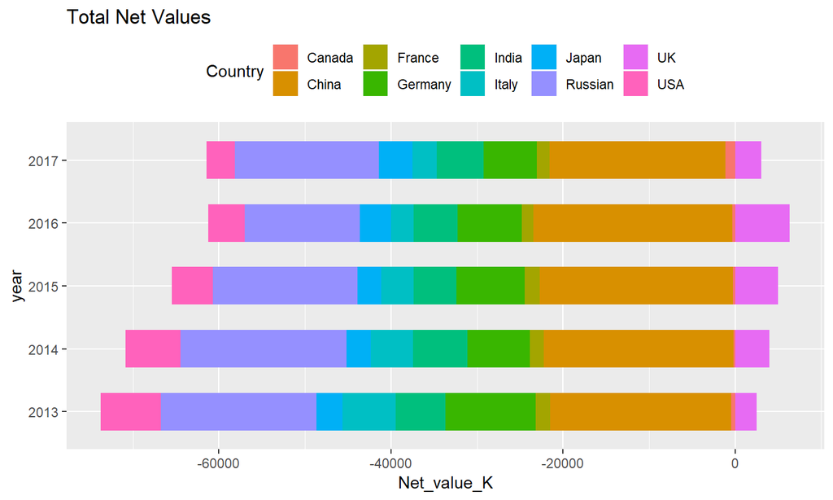

## Analysis

### Countries Effect on Trade Deficit

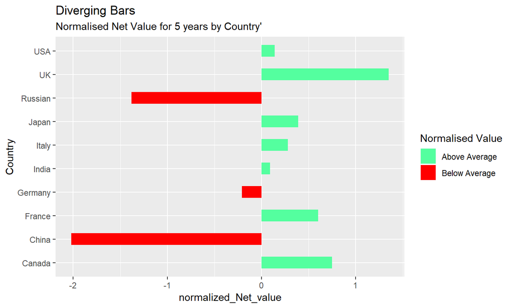

Discover more with *[Shiny](https://groupfour.shinyapps.io/tradeOrgProAnly/)*

## Analysis

### Correlation of Trade Deficit with FX Rate and BIST100 index

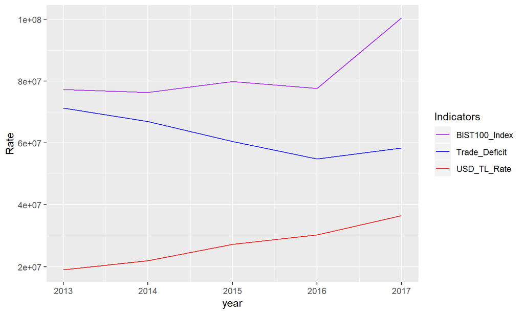

## Analysis

### Analysis of the Import Unit Prices and Export Unit Prices

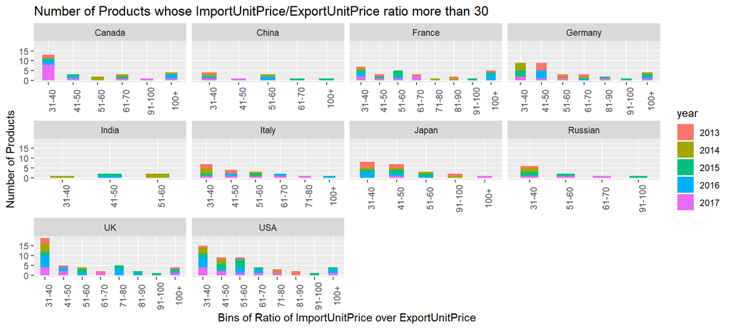

Discover more with *[Shiny](https://groupfour.shinyapps.io/tradeOrgProUnitP/)*